# Statistical Computing HW1

106033233 資工21 周聖諺

3/21/2021

## Problem 1:

### (a) Generate standard normal distribution by using Box-Muller approach with 10000 samples. Display the result by the histogram and the boxplot.

**Pseudo Code:**

Step 1. Generate $U_1$, $U_2$ from uniform $U(0, 1)$ independently

Step 2. Let variable

$$X = \sqrt{-2 ln \ U_1} \cos(2 \pi U_2)$$
$$Y = \sqrt{-2 ln \ U_1} \sin(2 \pi U_2)$$

Step 3. Return $X$ or $Y$, since $X, Y \stackrel{i.i.d}{\sim} N(0,1)$

```r
library(compositions)
```

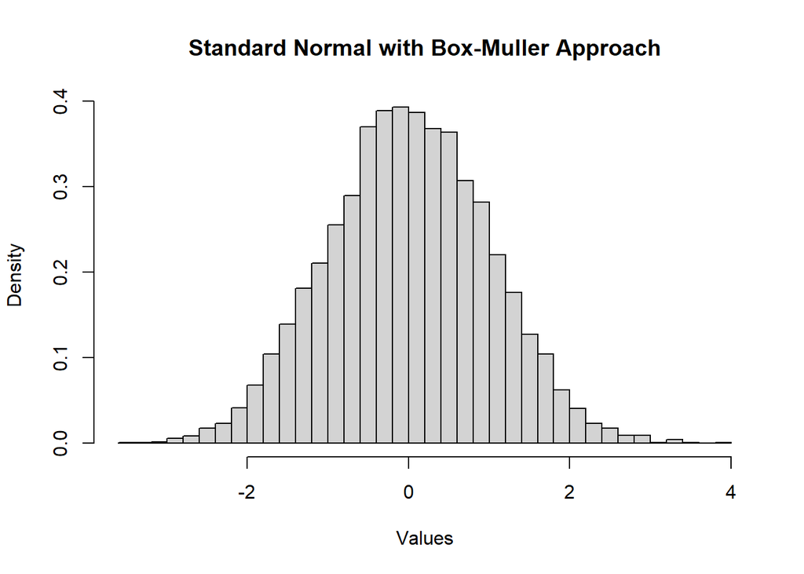

```r
normal_box_muller <- function(n){
  res <- vector("numeric", length=n)

  for (i in 0:n) {
    u1 <- runif(1, 0, 1)
    u2 <- runif(1, 0, 1)

    radius <- sqrt(-2 * log(u1))
    angle <- 2 * pi * u2

    x <- radius * cos(angle)
    y <- radius * sin(angle)

    #print(x)
    #print(y)

    res[i] <- x
  }

  return(res)
}
n <- 10000
res <- normal_box_muller(n)

hist(res, main="Standard Normal with Box-Muller Approach", xlab="Values", breaks=50, freq = FALSE)
```

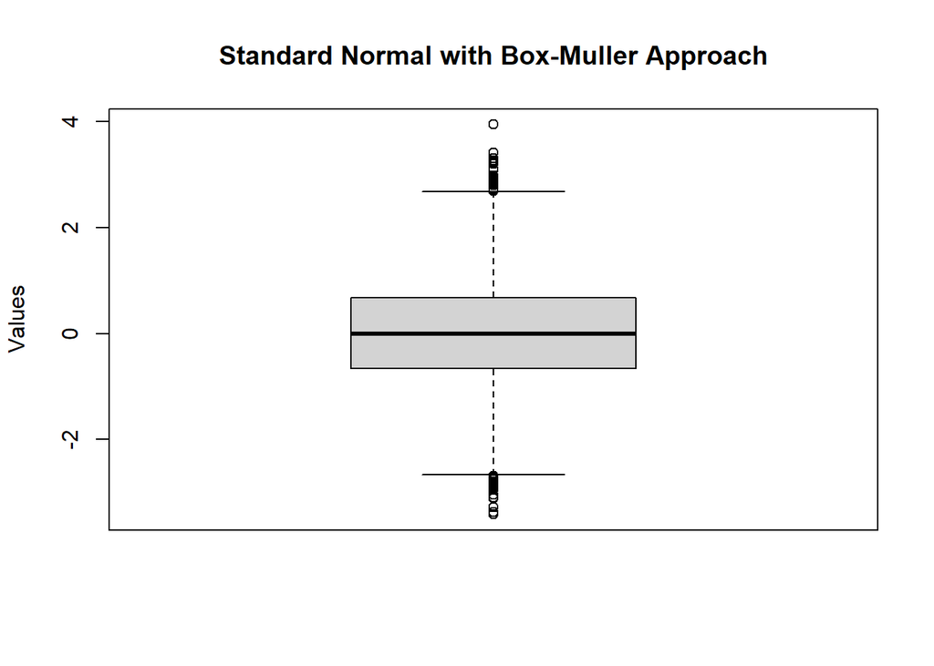

```r
boxplot(res, main="Standard Normal with Box-Muller Approach", ylab="Values", freq = FALSE)
```

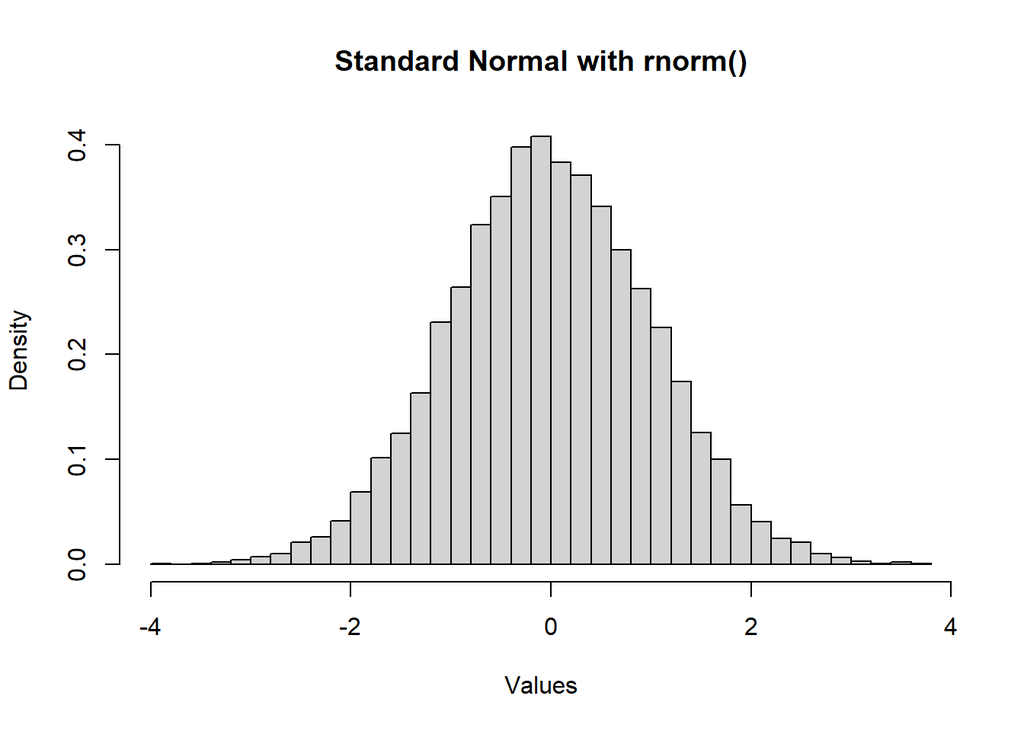

```r
r_dist <- rnorm(n, 0, 1)
hist(r_dist, main="Standard Normal with rnorm()", xlab="Values", breaks=50, freq = FALSE)
```

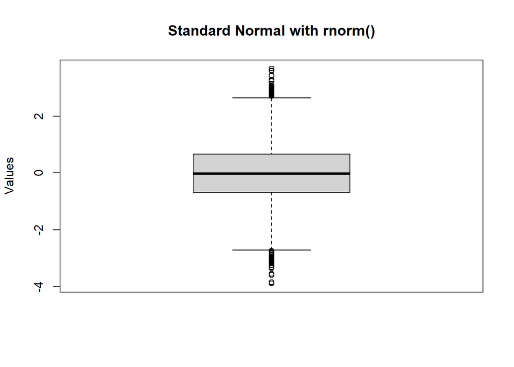

```r
boxplot(r_dist, main="Standard Normal with rnorm()", ylab="Values", freq = FALSE)
```

### (b) Generate standard normal distribution by using Acceptance and Rejection approach with 10000 samples. Display the result by the histogram and the boxplot.

**Pseudo Code Of Generating Exponential Distribution**

For $X \sim Exp(\lambda)$

Step 1. Generate $U \sim U(0, 1)$

Step 2. Return $-\frac{1}{\lambda} log U$

**Pseudo Code Of Generating Normal Distribution with Acceptance-Rejection Method:**

For $X \sim N(0, 1)$

Step 1. Generate $Y \sim Exp(1)$, $U_1 \sim U(0,1)$

Step 4. Return X

```r
exponential <- function(n, lambda){
  res <- vector("numeric", length=n)

  for (i in 1:n) {
    u <- runif(1, 0, 1)

    res[i] <- -(1/lambda) * log(u)
  }

  return(res)
}

normal_acc_rej <- function(n){
  res <- vector("numeric", length=n)
  total_num <- 0
  acc_num <- 0

  for (i in 1:n) {
    y <- exponential(1, 1)
    u1 <- runif(1, 0, 1)
    u2 <- runif(1, 0, 1)
    x <- 0
    total_num <- total_num + 1

    while (!(u1 <= exp(-((y - 1)**2) / 2))) {
      y <- exponential(1, 1)
      u1 <- runif(1, 0, 1)
      u2 <- runif(1, 0, 1)
      total_num <- total_num + 1
    }
    # Accept
    x <- y
    acc_num <- acc_num + 1

    if(u2 <= 0.5){
      x = abs(x)
    }else{
      x = -abs(x)
    }

    res[i] <- x
  }

  print("Acceptance Rate(%)")
  print(100*acc_num/total_num)

  return(res)
}

#n <- 10000
res <- normal_acc_rej(n)
```

```
## [1] "Acceptance Rate(%)"
## [1] 75.83801
```

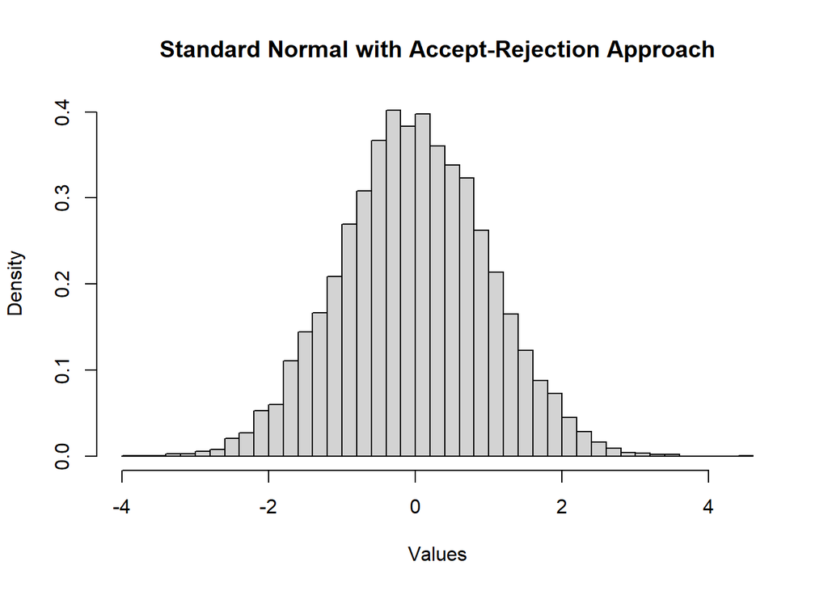

```r
hist(res, main="Standard Normal with Accept-Rejection Approach", xlab="Values", breaks=50, freq = FALSE)
```

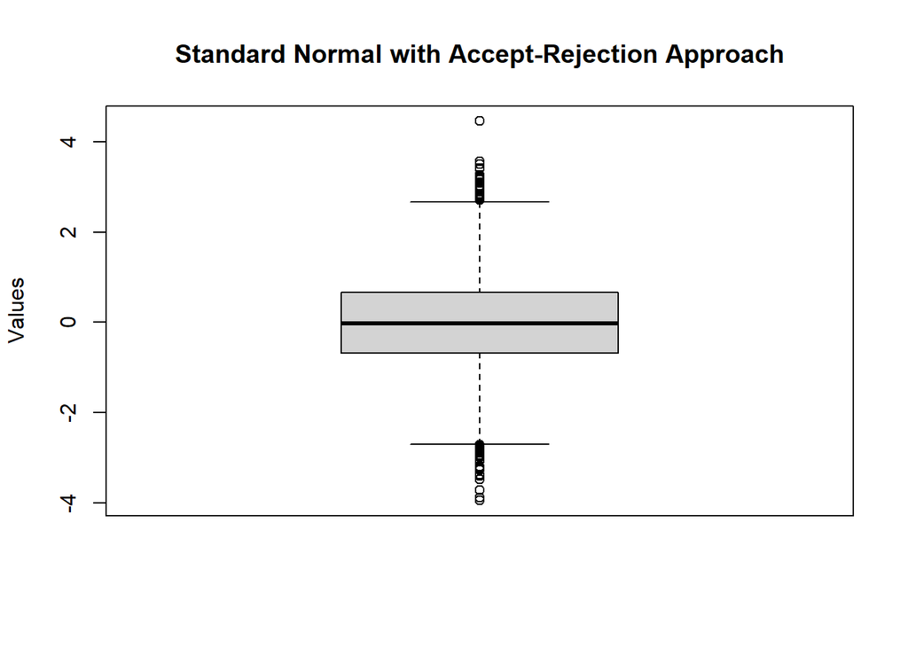

```r
boxplot(res, main="Standard Normal with Accept-Rejection Approach", ylab="Values", freq = FALSE)
```

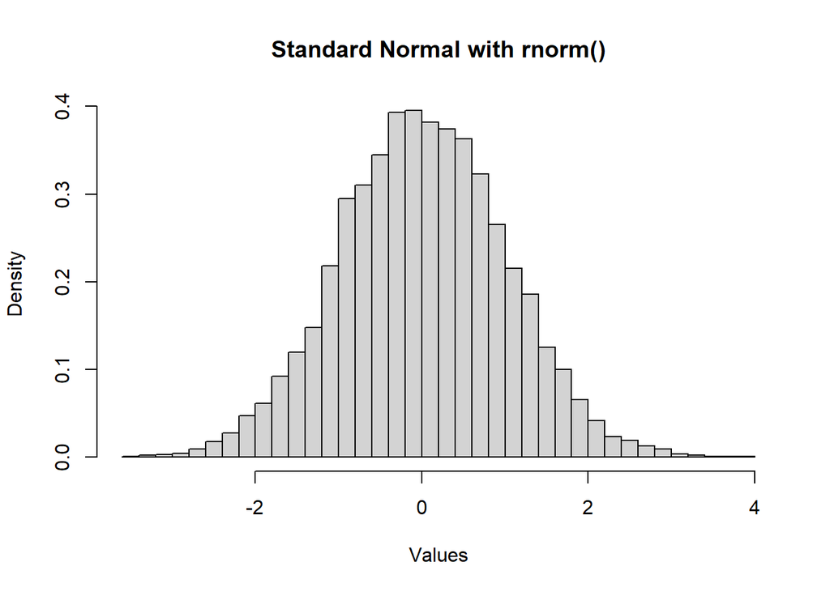

```r
r_dist <- rnorm(n, 0, 1)
hist(r_dist, main="Standard Normal with rnorm()", xlab="Values", breaks=50, freq = FALSE)
```

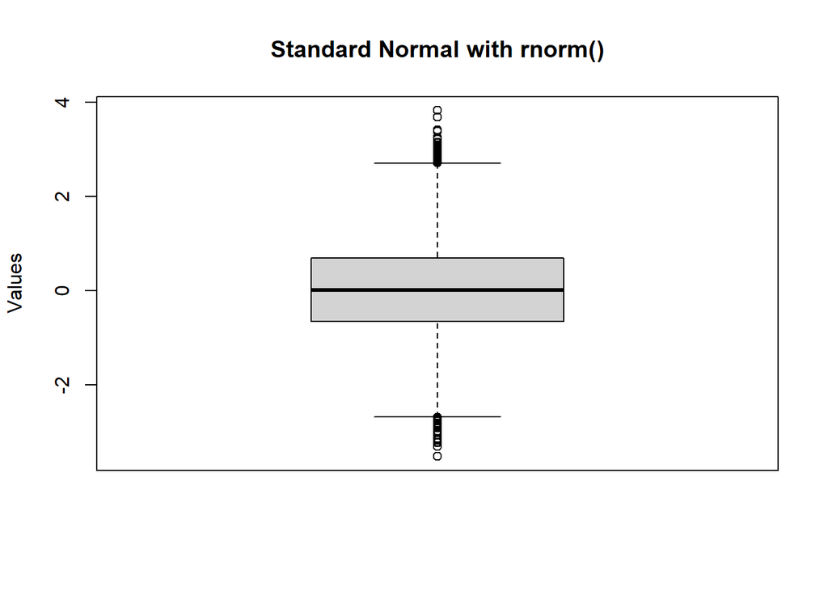

```r
boxplot(r_dist, main="Standard Normal with rnorm()", ylab="Values", freq = FALSE)
```

## Problem 2:

### (a) Generate Poisson distribution with 10000 samples. Display the result by the histogram and the boxplot.

$$X \sim Poisson(\mu = 10)$$

where $\lambda$ the happening rate of the event during $T$ time and the $\mu$ means the average occurrence of the event during $T$ time.

$$\lambda \cdot T = \mu$$

**Pseudo Code**

For $Poisson(\mu)$

Step 1. Let $t = 0, X = 0$

Step 2. If $t \leq \mu$, generate $U \sim U(0,1)$. Otherwise, go to Step 5.

Step 3. $t = t - log(U)$

Step 4. if $t \leq \mu$, $X = X + 1$. Otherwise, go back to Step 2.

Step 5. Return $X$

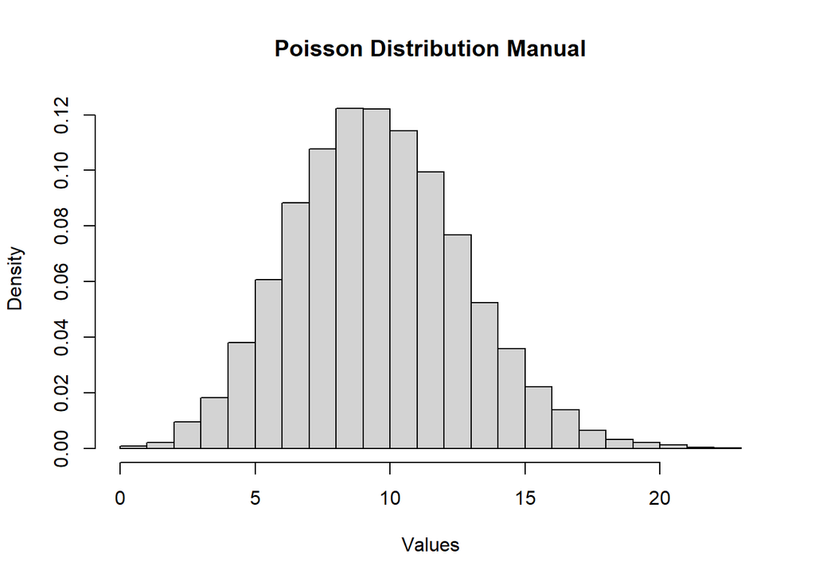

```r
poisson <- function(n, mu){
  res <- vector("numeric", length=n)

  for (i in 1:n) {
    T <- mu

    t <- 0
    x <- 0

    while (t <= T) {
      u <- runif(1, 0, 1)
      # lambda = 1
      t <- t - log(u)

      if(t <= as.numeric(T)){
        x <- x + 1
      }
    }

    res[i] <- x
  }

  return(res)
}

#n <- 10000
mu <- 10
res <- poisson(n, mu)

hist(res, main="Poisson Distribution Manual", xlab="Values", freq = FALSE, breaks=25)
```

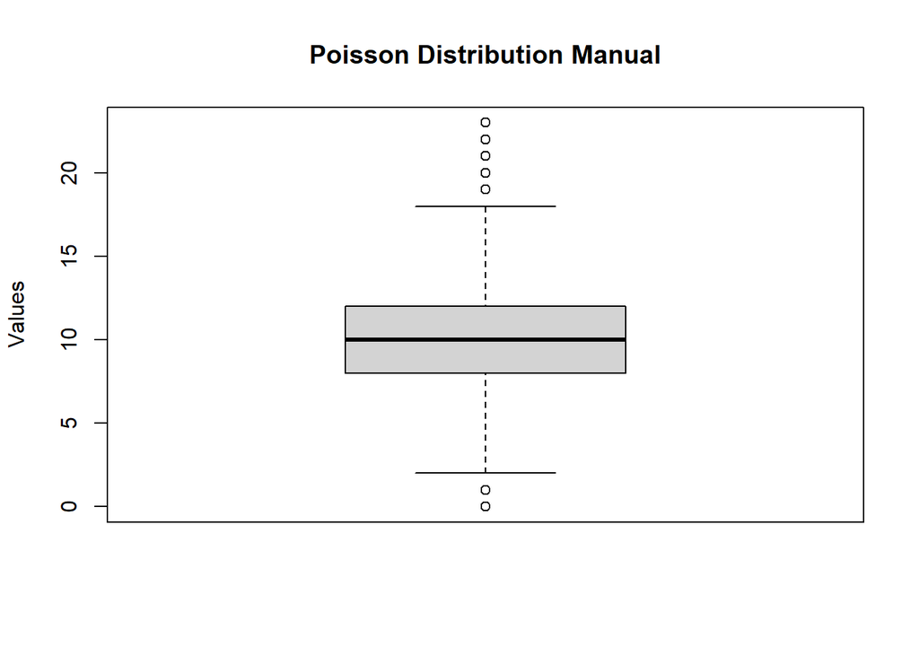

```r
boxplot(res, main="Poisson Distribution Manual", ylab="Values", freq = FALSE)
```

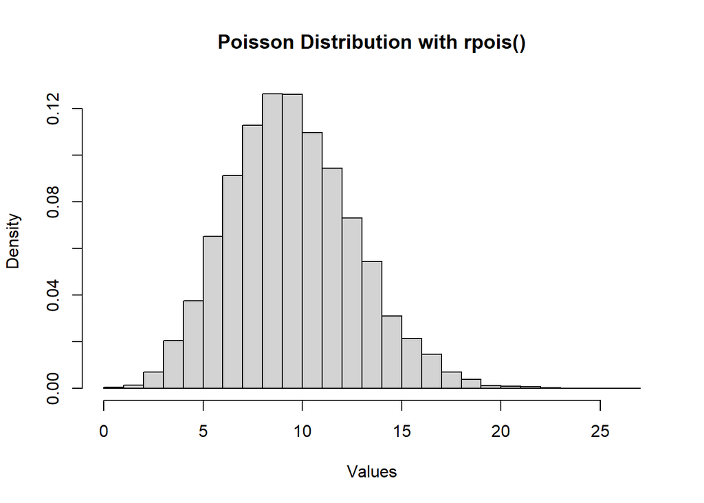

```r
r_dist <- rpois(n, mu)
hist(r_dist, main="Poisson Distribution with rpois()", xlab="Values", breaks=25, freq = FALSE)
```

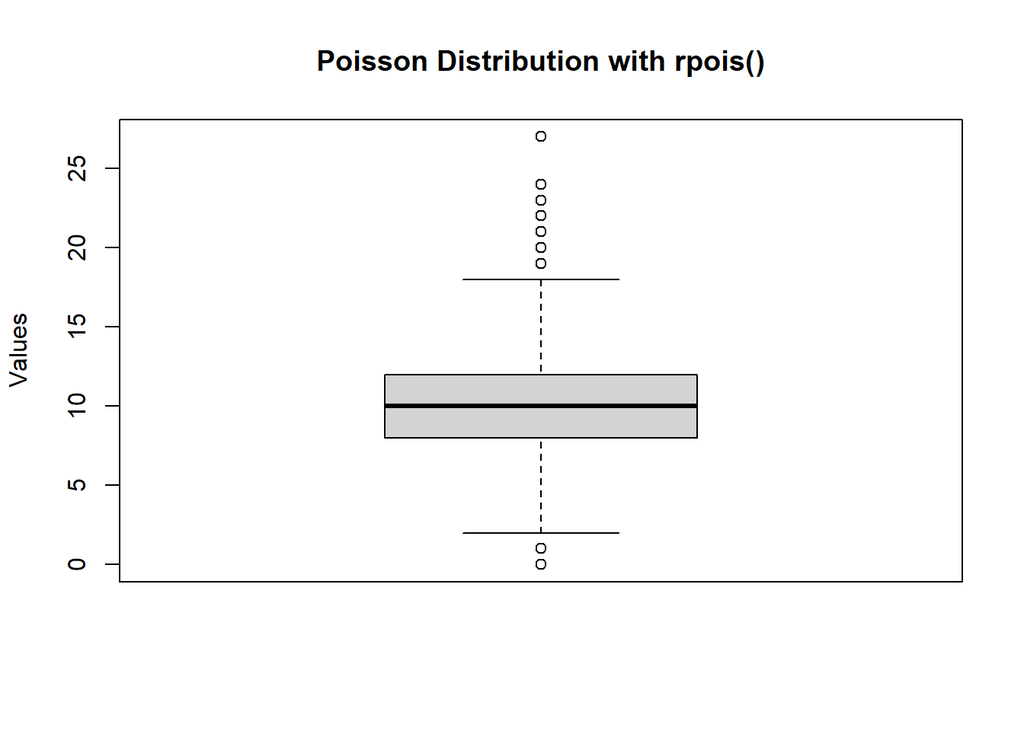

```r
boxplot(r_dist, main="Poisson Distribution with rpois()", ylab="Values", freq = FALSE)
```

### (b) Generate Gamma distribution with 10000 samples. Display the result by the histogram and the boxplot.

$X \sim Gamma(\alpha = 5, \beta = 3)$

**Pseudo Code**

For $Gamma(\alpha, \beta)$

Step 1. Generate $X_1, X_2, ..., X_{\alpha} \stackrel{i.i.d}{\sim} Exp(\beta)$

Step 2. Return $\sum_{i = 1}^{\alpha} X_i$

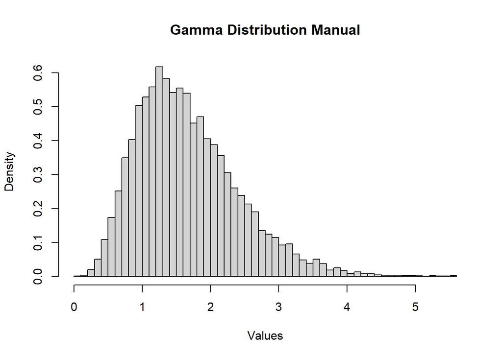

```r
gamma <- function(n, alpha, beta){
  res <- vector("numeric", length=n)

  for (i in 0:n) {
    # u <- runif(alpha, 0, 1)
    # y <- vector("numeric", length=alpha)

    # for (i in 0:alpha) {
      #y[i] <- -1 / beta * log(u[i])
    #}
    #res[i] <- sum(y)

    res[i] = sum(exponential(alpha, beta))
  }

  return(res)
}

#n <- 10000
alpha <- 5
beta <- 3
res <- gamma(n, alpha, beta)

hist(res, main="Gamma Distribution Manual", xlab="Values", freq = FALSE, breaks=50)
```

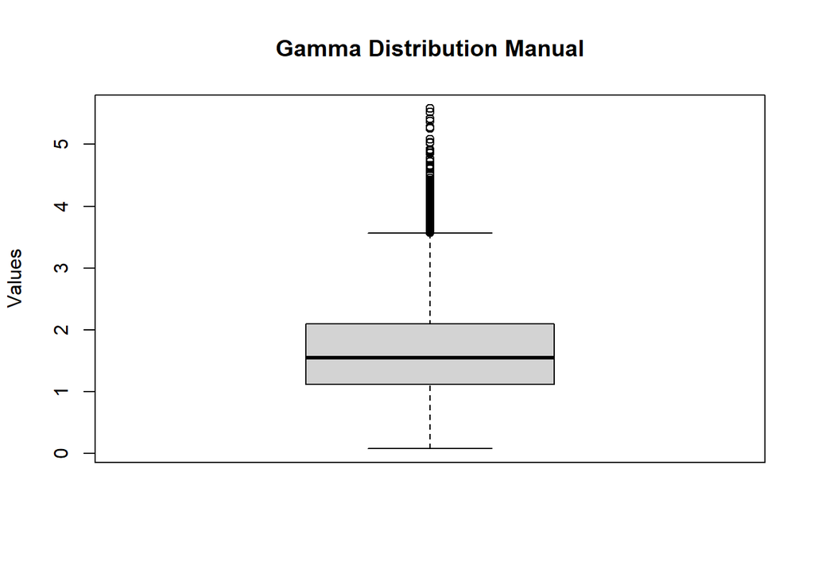

```r
boxplot(res, main="Gamma Distribution Manual", ylab="Values", freq = FALSE)
```

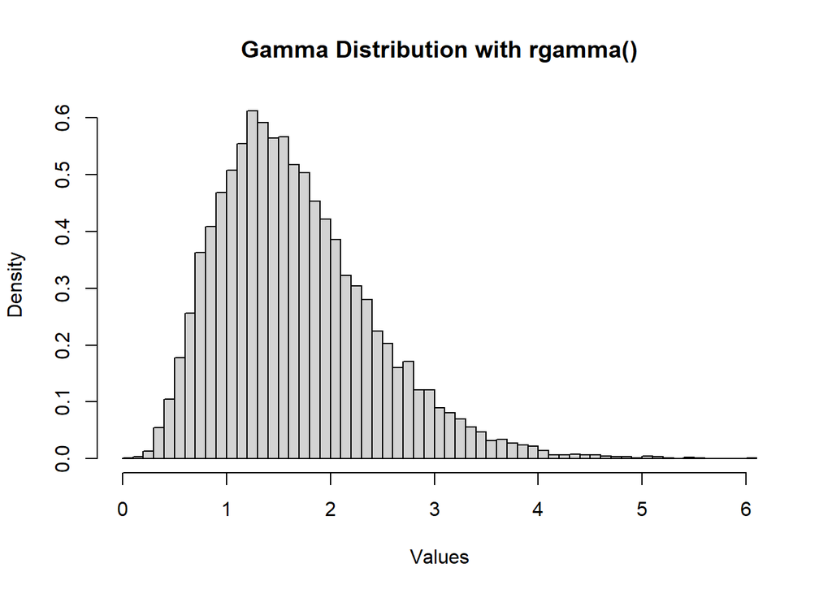

```r
r_dist <- rgamma(n, shape=alpha, rate=beta)
hist(r_dist, main="Gamma Distribution with rgamma()", xlab="Values", breaks=50, freq = FALSE)
```

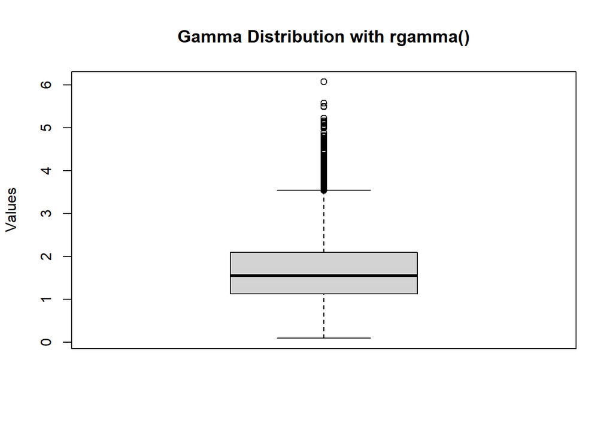

```r
boxplot(r_dist, main="Gamma Distribution with rgamma()", ylab="Values", freq = FALSE)
```

## Problem 3

### (a)

Suppose

$$X | \mu \sim Poisson(\mu) = \frac{\mu^x e^{-\mu}}{x!}$$

$$\mu \sim Gamma(\alpha, \beta) = \frac{\mu^{\alpha - 1} e^{-\frac{\mu}{\beta}}}{\beta^{\alpha} \Gamma(\alpha)}$$

The marginal distribution $f_X(x)$ of $X$ is

$$f_X(x) = \int_{\mu} p(X, \mu) \ d\mu = \int_{\mu} p(X|\mu)p(\mu) \ d\mu$$

$$= \int_{\mu} \frac{\mu^x e^{-\mu}}{x!} \cdot \frac{\mu^{\alpha - 1} e^{-\frac{\mu}{\beta}}}{\beta^{\alpha} \Gamma(\alpha)} \ d\mu$$

$$= \frac{1}{x! \Gamma(\alpha) \beta^{\alpha}} \int_0^{\infty} \mu^x e^{-\mu} \mu^{\alpha - 1} e^{-\frac{\mu}{\beta}} \ d\mu$$

$$= \frac{1}{x! \Gamma(\alpha) \beta^{\alpha}} \int_0^{\infty} \mu^{\alpha + x - 1} e^{-\mu (1 + \frac{1}{\beta})} \ d\mu$$

$$= \frac{1}{\Gamma(x + 1) \Gamma(\alpha) \beta^{\alpha}} \Gamma(\alpha + x) \frac{\beta}{1 + \beta}$$

$$= \begin{pmatrix}
\alpha - 1 + x\\
x
\end{pmatrix}
(\frac{1}{1+\beta})^{\alpha} \
(1 - \frac{1}{1+\beta})^{x}$$

Let $n = \alpha, p = \frac{1}{1 + \beta}$

$$= \begin{pmatrix}
n - 1 + x\\
x
\end{pmatrix} p^n (1 - p)^{x}$$

It is a Negative Binomial distribution $\mathcal{NB}(n, p)$

**Pseudo Code Of Geometric**

For $Geo(p)$

Step 1. Generate $U \sim U(0, 1)$

Step Return $\lfloor \frac{log \ U}{log \ (1 - p)} \rfloor$

**Pseudo Code Of Negative Binomial**

For $NB(n, p)$

Step 1. Generate $X_1, X_2, ..., X_{n} \stackrel{i.i.d}{\sim} Geo(p)$

Step 2. Return $\sum_{i = 1}^{n} X_i$

### (b)

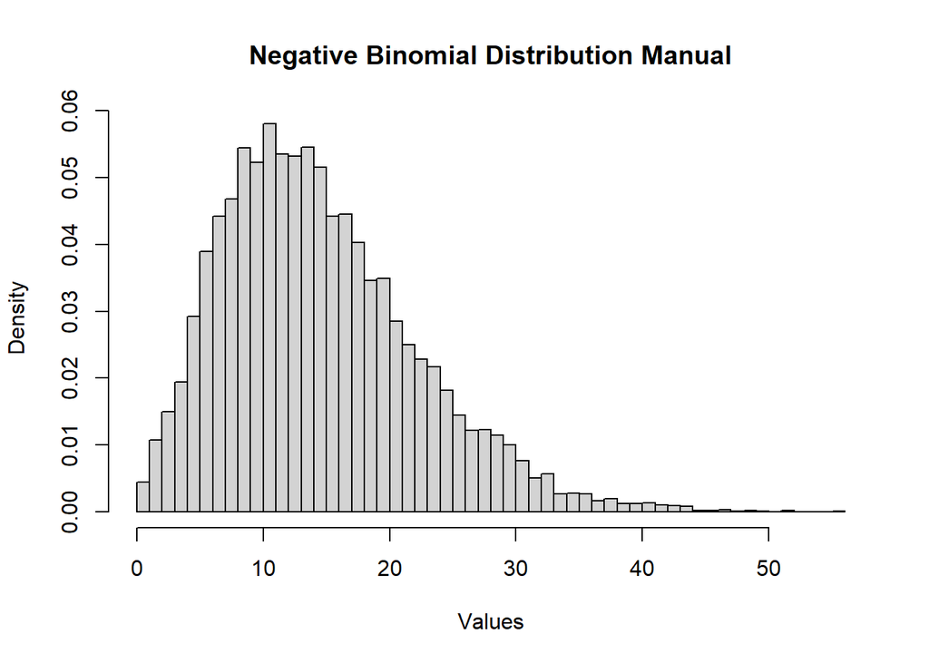

```r
geo <- function(n, p){
  res <- vector("numeric", length=n)

  for (i in 1:n) {
    u <- runif(1, 0, 1)
    #print(u)
    #print(log(u))
    #print(log(1 - p))
    res[i] <- floor(log(u) / log(1 - p))
  }

  return(res)
}

nb <- function(n, m, p){
  res <- vector("numeric", length=n)

  for (i in 1:n) {
    geo_res <- vector("numeric", length=m)

    geo_res <- geo(m, p)

    #print(geo_res)

    res[i] <- sum(geo_res)
  }

  return(res)
}

#n <- 10000
alpha <- 5
beta <- 3
res <- nb(n, alpha, 1/(1 + beta))

#print(res)

hist(res, main="Negative Binomial Distribution Manual", xlab="Values", freq = FALSE, breaks=50)
```

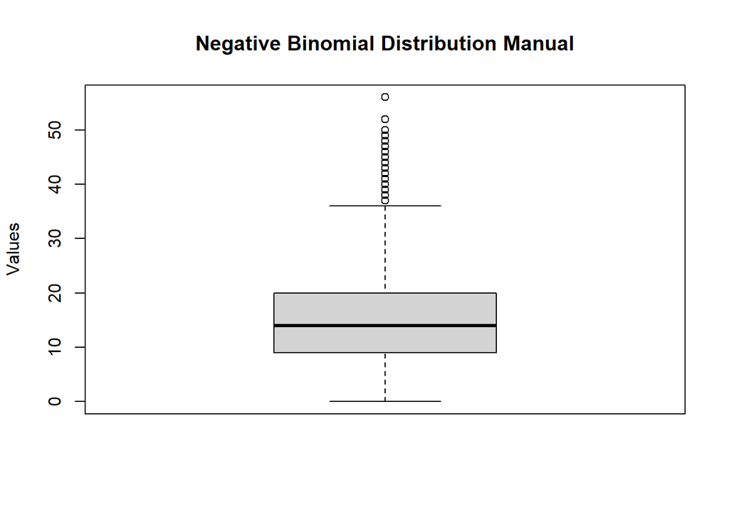

```r
boxplot(res, main="Negative Binomial Distribution Manual", ylab="Values", freq = FALSE)
```

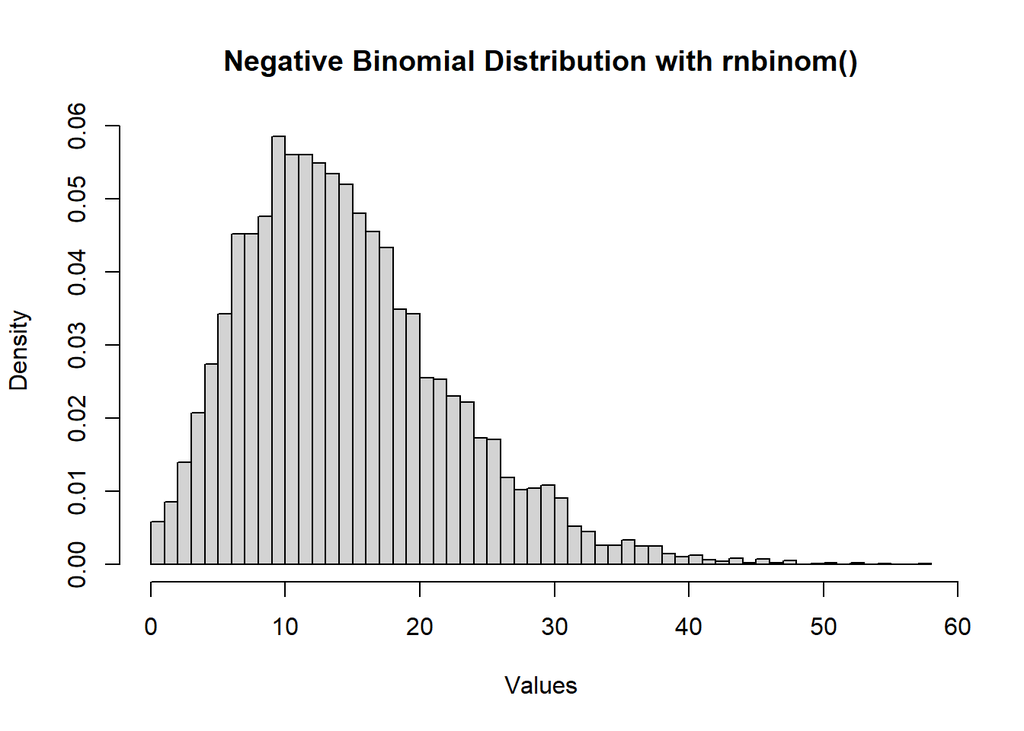

```r
r_dist <- rnbinom(n, alpha, 1/(1 + beta))
hist(r_dist, main="Negative Binomial Distribution with rnbinom()", xlab="Values", breaks=50, freq = FALSE)
```

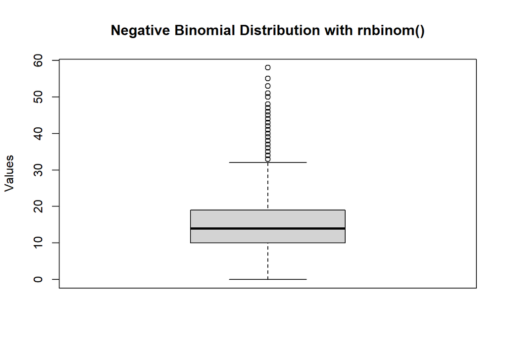

```r
boxplot(r_dist, main="Negative Binomial Distribution with rnbinom()", ylab="Values", freq = FALSE)
```

### (c) What are the mean and variance of $X$?

# Problem 4

### (a)

$$X_1 \sim \mathcal{N}(\mu_1, \sigma_1^2), \ X_2 \sim \mathcal{N}(\mu_2, \sigma_2^2)$$

A mixture model of $X_1, X_2$

$$f_{X_1, X_2}(x) = p_1 \cdot p_{X_1}(x) + p_2 \cdot p_{X_2}(x)$$

$$= p_1 \cdot \frac{1}{\sigma_1 \sqrt{2 \pi}} e^{- \frac{1}{2} (\frac{x-\mu_1}{\sigma_1})^2} + p_2 \cdot \frac{1}{\sigma_2 \sqrt{2 \pi}} e^{- \frac{1}{2} (\frac{x-\mu_2}{\sigma_2})^2}$$

Let $\mu_1 = 0, \mu_2 = 3$ and $\sigma_1^2 = \sigma_2^2 = 1$

$$= p_1 \cdot \frac{1}{\sqrt{2 \pi}} e^{- \frac{1}{2} x^2} + (1 - p_1) \cdot \frac{1}{\sqrt{2 \pi}} e^{- \frac{1}{2} (x-3)^2}$$

### (b)

Let $p_1 = 0.75$ and generate 10000 samples from the mixture model.

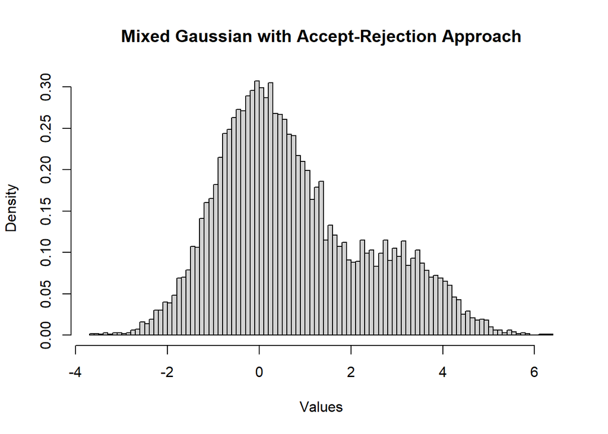

```r
mix_acc_rej <- function(n, p_1, mu_1, mu_2, sigma_1, sigma_2){
  res <- vector("numeric", length=n)

  for (i in 0:n) {
    p <- runif(1, 0, 1)
    shift <- 0
    scale <- 0
    if(p <= p_1){
      shift <- mu_1
      scale <- sigma_1
    }else{
      shift <- mu_2
      scale <- sigma_2
    }

    y <- exponential(1, 1)
    u1 <- runif(1, 0, 1)
    u2 <- runif(1, 0, 1)
    x <- 0

    while (!(u1 <= exp(-((y - 1)**2) / 2))) {
      y <- rexp(1, 1)
      u1 <- runif(1, 0, 1)
      u2 <- runif(1, 0, 1)
    }
    # Accept
    x <- y

    if(u2 <= 0.5){
      x = abs(x)
    }else{
      x = -abs(x)
    }

    x <- x * scale + shift

    res[i] <- x
  }

  return(res)
}

#n <- 10000
res <- mix_acc_rej(n, 0.75, 0, 3, 1, 1)

hist(res, main="Mixed Gaussian with Accept-Rejection Approach", xlab="Values", breaks=100, freq = FALSE)
```

The distribution seems bimodal.